```python
import pandas as pd
import numpy as np
from datetime import datetime
import matplotlib.pyplot as plt
import seaborn as sns
from sklearn.linear_model import LinearRegression
import statsmodels
from pmdarima import auto_arima
```

# IE 423 - PROJECT PART 2

## FETHİ KAHVECİOĞLU

Before we started working on the data, we transformed it to the shorter format so that we can work and visualize the data more convenient way. The transformation and the formatting method has been done in the initial stages of our study and it is saved as this way. Due to the poor file management, we cannot propose the transformation method now but the end result. For the missing data of N/A's we used the linear interpolation method.

```python
# Load the data from the CSV file
file_path = '/Users/mustafacan/Downloads/all_datasss.csv'
data = pd.read_csv(file_path)

# Display the first few rows of the dataset for an overview
data.head()
```

|  | Unnamed: 0 | timestamp | AKBNK | ARCLK | ASELS | BIMAS | DOHOL | EKGYO | EREGL | FROTO | ... | SISE | TAVHL | TCELL | THYAO | TKFEN | TTKOM | TUPRS | VAKBN | VESTL | YKBNK |
| --- | --- | --- | --- | --- | --- | --- | --- | --- | --- | --- | --- | --- | --- | --- | --- | --- | --- | --- | --- | --- | --- |
| 0 | 0 | 2018-01-02 09:00:00+03:00 | 6.9475 | 18.4146 | 7.9405 | 31.8609 | 0.7028 | 2.3141 | 6.0021 | 42.0959 | ... | 4.0562 | 18.4807 | 12.1212 | 15.79 | 12.7352 | 4.9603 | 12.2392 | 6.6842 | 5.9926 | 2.4490 |
| 1 | 1 | 2018-01-02 10:00:00+03:00 | 7.0602 | 18.4999 | 7.9549 | 32.2076 | 0.7110 | 2.3387 | 6.0199 | 42.3053 | ... | 4.0049 | 18.6442 | 12.1604 | 16.01 | 12.7952 | 5.0726 | 12.3095 | 6.7927 | 6.1659 | 2.4659 |
| 2 | 2 | 2018-01-02 11:00:00+03:00 | 7.0954 | 18.3804 | 7.9405 | 32.0850 | 0.7110 | 2.3306 | 5.9962 | 42.6195 | ... | 4.0305 | 18.5788 | 12.0586 | 16.05 | 12.6978 | 5.0726 | 12.2894 | 6.8715 | 6.4809 | 2.4828 |
| 3 | 3 | 2018-01-02 12:00:00+03:00 | 7.0814 | 18.3633 | 7.9694 | 31.9017 | 0.7110 | 2.3387 | 5.9962 | 42.7939 | ... | 4.0305 | 18.6278 | 12.0509 | 16.05 | 12.5855 | 5.0565 | 12.2995 | 6.8715 | 6.5202 | 2.4828 |
| 4 | 4 | 2018-01-02 13:00:00+03:00 | 7.1024 | 18.3633 | 7.9742 | 32.0443 | 0.7189 | 2.3387 | 6.0080 | 42.6544 | ... | 4.0305 | 18.6278 | 12.1057 | 16.06 | 12.5855 | 5.0565 | 12.3195 | 6.8814 | 6.5202 | 2.4828 |

5 rows × 32 columns

```python
# Dropping the irrelevant column
data_cleaned = data.drop(data.columns[0], axis=1)

# Display the first few rows of the cleaned dataset
data_cleaned.head()

data = data_cleaned
```

```python
# Updating the code to address the deprecation issues
# Calculating the correlation matrix
correlation_matrix_updated = data_cleaned.drop('timestamp', axis=1).corr()

# Focusing on the upper triangle to avoid redundant pairs
upper_triangle_correlation_updated = correlation_matrix_updated.where(
    ~np.tril(np.ones(correlation_matrix_updated.shape)).astype(bool)
)

# Extracting the pairs and their correlation coefficients
correlation_pairs_updated = upper_triangle_correlation_updated.stack().reset_index()
correlation_pairs_updated.columns = ['Company 1', 'Company 2', 'Correlation Coefficient']

correlation_pairs_updated.head()  # Displaying the first few pairs for a preview
```

|  | Company 1 | Company 2 | Correlation Coefficient |
| --- | --- | --- | --- |
| 0 | AKBNK | ARCLK | 0.927587 |
| 1 | AKBNK | ASELS | 0.960144 |
| 2 | AKBNK | BIMAS | 0.956508 |
| 3 | AKBNK | DOHOL | 0.952171 |
| 4 | AKBNK | EKGYO | 0.917057 |

```python
# Sorting the pairs by correlation coefficient in descending order
top_correlation_pairs = correlation_pairs_updated.sort_values(by='Correlation Coefficient', ascending=False)

# Selecting the top 5 pairs
top_5_correlation_pairs = top_correlation_pairs.head(5)
top_5_correlation_pairs
```

|  | Company 1 | Company 2 | Correlation Coefficient |
| --- | --- | --- | --- |
| 362 | PGSUS | THYAO | 0.993034 |
| 7 | AKBNK | GARAN | 0.992619 |
| 298 | KCHOL | YKBNK | 0.989403 |
| 281 | ISCTR | YKBNK | 0.988707 |
| 370 | SAHOL | SISE | 0.988279 |

- We find the top 5 correlated company pairs which we will proceed with PGSUS&THYAO and AKBNK&GARAN.

```python
# Convert the timestamp column to datetime and set as index
data_cleaned['timestamp'] = pd.to_datetime(data_cleaned['timestamp'])
data_with_datetime_index = data_cleaned.set_index('timestamp')

# PGSUS and THYAO
pgsus_thyao_data = data_with_datetime_index[['PGSUS', 'THYAO']]

# AKBNK and GARAN
akbnk_garan_data = data_with_datetime_index[['AKBNK', 'GARAN']]

# Displaying the first few rows to verify the changes
pgsus_thyao_data.head()
```

| timestamp | PGSUS | THYAO |
| --- | --- | --- |
| 2018-01-02 09:00:00+03:00 | 33.98 | 15.79 |
| 2018-01-02 10:00:00+03:00 | 34.28 | 16.01 |
| 2018-01-02 11:00:00+03:00 | 35.02 | 16.05 |
| 2018-01-02 12:00:00+03:00 | 35.10 | 16.05 |
| 2018-01-02 13:00:00+03:00 | 35.08 | 16.06 |

```python
# Function to create and display control charts directly in the coding interface
def display_control_chart(data, start_date, end_date):
    interval_data = data[start_date:end_date]

    if interval_data.empty:
        return

    # Linear regression
    X = interval_data['PGSUS'].values.reshape(-1, 1)
    y = interval_data['THYAO'].values
    model = LinearRegression().fit(X, y)
    y_pred = model.predict(X)

    # Calculating residuals
    residuals = y - y_pred

    # Control chart parameters
    mean_residuals = np.mean(residuals)
    std_residuals = np.std(residuals)
    upper_control_limit = mean_residuals + 1.5 * std_residuals
    lower_control_limit = mean_residuals - 1.5 * std_residuals

    # Plotting the control chart
    fig, ax = plt.subplots(figsize=(10, 5))
    ax.plot(interval_data.index, residuals, marker='.', linestyle='', color='blue', label='Residuals')
    ax.axhline(mean_residuals, color='green', linestyle='--', label='Mean')
    ax.axhline(upper_control_limit, color='red', linestyle='-', label='Upper Control Limit (UCL)')
    ax.axhline(lower_control_limit, color='red', linestyle='-', label='Lower Control Limit (LCL)')
    ax.set_title(f"Control Chart for Residuals: {start_date.strftime('%Y-%m')} to {end_date.strftime('%Y-%m')}")
    ax.set_xlabel('Date')
    ax.set_ylabel('Residuals')
    ax.legend()

    plt.show()

    print(start_date)
```

The below chart explains how we built the control charts. We update our control charts when the simulation goes up one time unit which is hours. In this part the 3 months of the data is visualized and the control charts are built upon that. Every time we iterate over the horizon, we built the control chart dynamically. In the simulation, we mainly work with 6 months of past data due to better training and comprehensivity.

The 1.5 sigma limit is obtained in this study due to the pair trading strategy work. More wider limits obligates the trading event to occur.

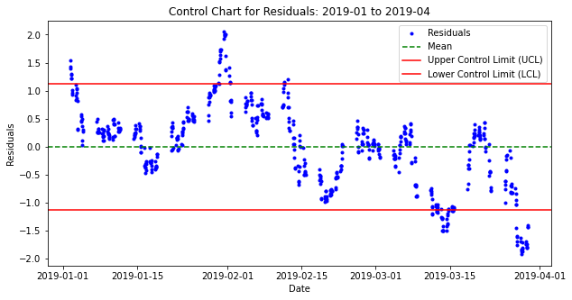

```
2019-01-01 00:00:00+03:00
```

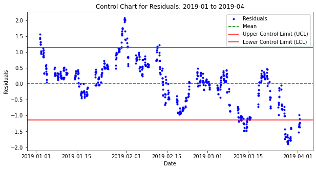

```
2019-01-02 00:00:00+03:00
```

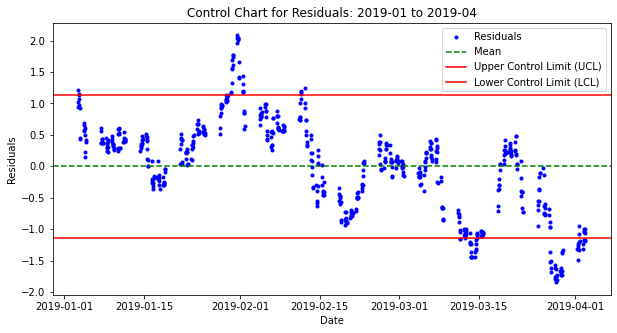

```
2019-01-03 00:00:00+03:00
```

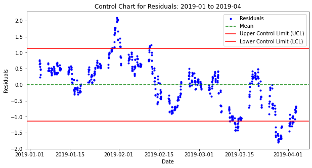

```
2019-01-04 00:00:00+03:00
```

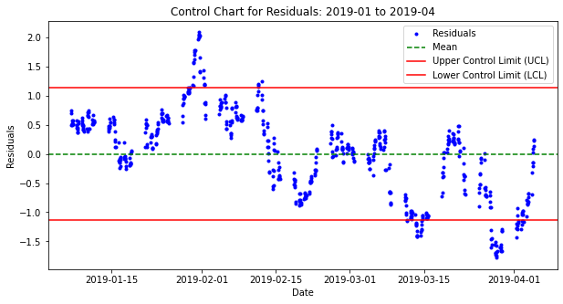

```
2019-01-05 00:00:00+03:00
```

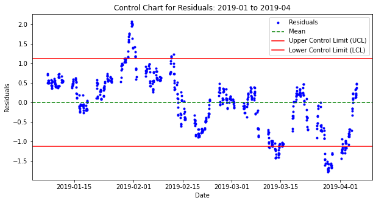

```
2019-01-06 00:00:00+03:00
```

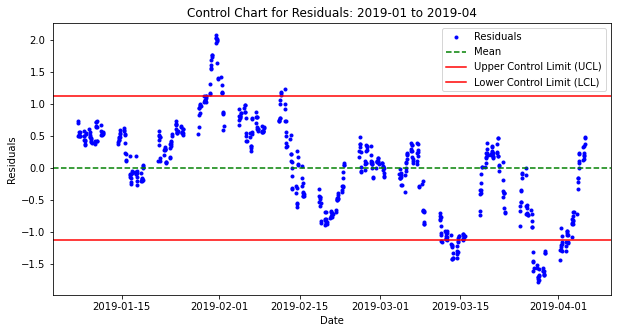

```
2019-01-07 00:00:00+03:00
```

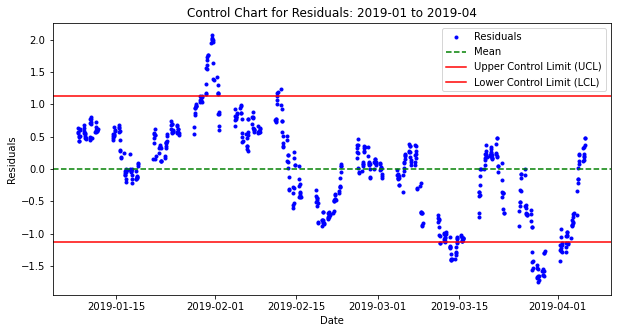

```
2019-01-08 00:00:00+03:00
```

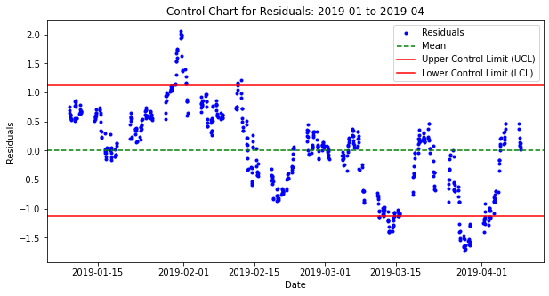

```
2019-01-09 00:00:00+03:00
```

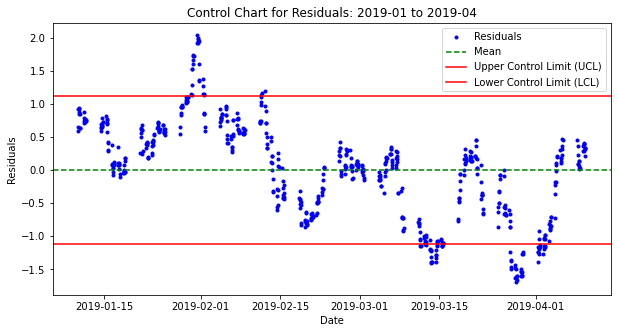

```
2019-01-10 00:00:00+03:00
```

```python
# Adjusting the code to use timezone-aware datetime objects for indexing

# Extracting the timezone from the dataframe's index
timezone = pgsus_thyao_data.index.tz

# Displaying control charts for each three-month interval in 2018 with timezone-aware datetime objects
for day in range(1, 11):
    start_of_interval = datetime(2019, 1, day, tzinfo=timezone)
    end_of_interval = start_of_interval + pd.DateOffset(months=3)
    display_control_chart(pgsus_thyao_data, start_of_interval, end_of_interval)
```

Moving up with our simulation.

trading_simulation_all_in, simulates a trading strategy based on linear regression and control chart principles for a specified duration. Here's a summary of its key components and processes:

Input Parameters: data: A dataset containing historical price information. capital: The starting capital for trading. start_date: The initial date for the simulation. trading_duration: The duration of the trading simulation, expressed in days. stock1, stock2: The two stock tickers used in the trading pair.

Initialization: The function initializes various variables for tracking trades, current stock holdings, and the last signal (indicating upper or lower threshold breach).

Data Preparation: The data is reset and indexed for easy access. The simulation period is set to a range of 6 months, starting 6 months prior to the provided start_date. The control charts are built for the 6 month prior to the trading time unit. The training data is comprehends the 6 months time horizon to be trained and the control chart is built for that time, then the present daha is checked whether it conforms the limits or not.

Trading Logic: The function runs a loop for the duration of the trading simulation, performing actions every hour (10 times a day). In each iteration, a linear regression model is fitted between the prices of stock1 and stock2. Residuals (differences between actual and predicted values) are calculated. Control chart limits are set at 1.5 standard deviations from the mean of residuals. Trading signals are generated based on whether the latest residual crosses these limits. If the residual is below the lower limit and the last signal wasn't 'lower', it triggers a buy action for stock1. If the residual is above the upper limit and the last signal wasn't 'upper', it triggers a buy action for stock2. Trades are made by selling the current holdings (if any) and buying as many shares as possible of the signaled stock with the available capital.

Trade Execution: The function records each trade, updating the capital and the quantity of stock held after each transaction. Final Accounting: At the end of the simulation, the final value of the securities held is calculated.

Output: The function returns a list of all trades, the remaining capital, and the final value of the securities held. This function represents a simplified trading simulation using a pairs trading strategy, driven by a regression-based approach and control chart methodology for signal generation.

```python
# The function that simulates for "trading_duration" days for given pairs starting with a given "capital".
# The function uses regression model for residuals.

def trading_simulation_all_in(data, capital, start_date, trading_duration:int, stock1, stock2):
    # Trade records, current stock holding, and last signal
    trades = []
    current_stock = None  # None, stock1, stock2
    last_signal = None  # None, 'upper', 'lower'

    data = data.reset_index()
    new_indexes = data.index.tolist()
    timestamps_list = data['timestamp'].tolist()

    start_date = start_date - pd.DateOffset(months=6)
    end_date = start_date + pd.DateOffset(months=6)

    start_date_index = timestamps_list.index(min(timestamps_list, key=lambda x: abs(x - start_date)))
    end_date_index = timestamps_list.index(min(timestamps_list, key=lambda x: abs(x - end_date)))
    interval_data = data[start_date_index:end_date_index]

    for i in range(trading_duration * 10):
        # Linear regression
        X = interval_data[stock2].values.reshape(-1, 1)
        y = interval_data[stock1].values
        model = LinearRegression().fit(X, y)
        y_pred = model.predict(X)

        # Calculating residuals
        residuals = y - y_pred

        # Control chart parameters with 1.5σ limits
        mean_residuals = np.mean(residuals)
        std_residuals = np.std(residuals)
        upper_control_limit = mean_residuals + 1.5 * std_residuals
        lower_control_limit = mean_residuals - 1.5 * std_residuals

        if residuals[-1] < lower_control_limit and last_signal != 'lower':
            last_signal = 'lower'
            if current_stock == stock2:
                # Sell all stock2 shares
                capital += interval_data[stock2][end_date_index - 1] * stock_quantity
                trades.append({'Action': f'Sell {stock2}', 'Price': interval_data[stock2][end_date_index - 1], 'Quantity': stock_quantity})
                stock_quantity = 0

            # Buy as many stock1 shares as possible
            stock_quantity = capital // interval_data[stock1][end_date_index - 1]
            capital -= interval_data[stock1][end_date_index - 1] * stock_quantity
            trades.append({'Action': f'Buy {stock1}', 'Price': interval_data[stock1][end_date_index - 1], 'Quantity': stock_quantity})
            current_stock = stock1

        elif residuals[-1] > upper_control_limit and last_signal != "upper":
            last_signal = 'upper'
            if current_stock == stock1:
                # Sell all stock1 shares
                capital += interval_data[stock1][end_date_index - 1] * stock_quantity
                trades.append({'Action': f'Sell {stock1}', 'Price': interval_data[stock1][end_date_index - 1], 'Quantity': stock_quantity})
                stock_quantity = 0

            # Buy as many stock2 shares as possible
            stock_quantity = capital // interval_data[stock2][end_date_index - 1]
            capital -= interval_data[stock2][end_date_index - 1] * stock_quantity
            trades.append({'Action': f'Buy {stock2}', 'Price': interval_data[stock2][end_date_index - 1], 'Quantity': stock_quantity})
            current_stock = stock2


        # End of iteration
        start_date_index += 1
        end_date_index += 1
        interval_data = data[start_date_index:end_date_index]



    # Calculating the final value of securities held
    final_stock_value = 0
    if current_stock == stock2:
        final_stock_value = stock_quantity * interval_data.iloc[-1][stock2]
    elif current_stock == stock1:
        final_stock_value = stock_quantity * interval_data.iloc[-1][stock1]

    return trades, round(capital, 2), final_stock_value
```

```python
# Testing regression

# Parameter for THYAO and PGSUS
cap = 10000
time_dur = 180

complete_trades, final_cash_balance, final_stock_value = trading_simulation_all_in(pgsus_thyao_data, cap, datetime(2019, 1, 1, tzinfo=timezone), time_dur, "THYAO", "PGSUS")

print(f"Starting capital: {cap}")
print(f"Ending stock value: {final_stock_value}")
print(f"Final capital: {final_cash_balance}")
print(f"Total value: {final_stock_value + final_cash_balance}", end="\n\n")

print("Trades:")
for item in complete_trades:
    print(item)
```

```
Starting capital: 10000
Ending stock value: 13468.5
Final capital: 33.6
Total value: 13502.1

Trades:
{'Action': 'Buy THYAO', 'Price': 14.71, 'Quantity': 679.0}
{'Action': 'Sell THYAO', 'Price': 13.23, 'Quantity': 679.0}
{'Action': 'Buy PGSUS', 'Price': 40.92, 'Quantity': 219.0}
```

```python
# Testing regression

# Parameter for AKBNK and GARAN
cap = 10000
time_dur = 180

complete_trades, final_cash_balance, final_stock_value = trading_simulation_all_in(akbnk_garan_data, cap, datetime(2019, 1, 1, tzinfo=timezone), time_dur, "AKBNK", "GARAN")

print(f"Starting capital: {cap}")
print(f"Ending stock value: {final_stock_value}")
print(f"Final capital: {final_cash_balance}")
print(f"Total value: {final_stock_value + final_cash_balance}", end="\n\n")

print("Trades:")
for item in complete_trades:
    print(item)
```

```
Starting capital: 10000
Ending stock value: 14474.821999999998
Final capital: 0.35
Total value: 14475.171999999999

Trades:
{'Action': 'Buy AKBNK', 'Price': 4.9239, 'Quantity': 2030.0}
{'Action': 'Sell AKBNK', 'Price': 6.0478, 'Quantity': 2030.0}
{'Action': 'Buy GARAN', 'Price': 8.159, 'Quantity': 1505.0}
{'Action': 'Sell GARAN', 'Price': 8.7825, 'Quantity': 1505.0}
{'Action': 'Buy AKBNK', 'Price': 5.8508, 'Quantity': 2259.0}
{'Action': 'Sell AKBNK', 'Price': 5.5167, 'Quantity': 2259.0}
{'Action': 'Buy GARAN', 'Price': 7.4019, 'Quantity': 1684.0}
```

### Some sort of modified version of simple pair trading strategy.

- The difference lies on the trading logic

Trading Logic: The function iterates over the trading duration, performing 10 iterations per day. In each iteration: A linear regression model is fitted between the prices of stock1 and stock2. Residuals are calculated, and control chart limits are set at 1.5 standard deviations from the mean of residuals. The function checks the latest residual against these limits. If the residual is below the lower limit and the last signal was not 'lower', it triggers a buy action for stock1. If the residual is above the upper limit and the last signal was not 'upper', it triggers a buy action for stock2. If the residual stays within the limits for 5 consecutive iterations and there are holdings, it triggers a sell action for the current stock.

```python
# The function that simulates for "trading_duration" days for given pairs starting with a given "capital".
# The function uses regression model for residuals.

def trading_simulation_all_in_2(data, capital, start_date, trading_duration:int, stock1, stock2):
    # Trade records, current stock holding, and last signal
    trades = []
    current_stock = None  # None, stock1, stock2
    last_signal = None  # None, 'upper', 'lower'

    data = data.reset_index()
    new_indexes = data.index.tolist()
    timestamps_list = data['timestamp'].tolist()

    start_date = start_date - pd.DateOffset(months=6)
    end_date = start_date + pd.DateOffset(months=6)

    start_date_index = timestamps_list.index(min(timestamps_list, key=lambda x: abs(x - start_date)))
    end_date_index = timestamps_list.index(min(timestamps_list, key=lambda x: abs(x - end_date)))
    interval_data = data[start_date_index:end_date_index]

    control_count = 0

    for i in range(trading_duration * 10):
        # Linear regression
        X = interval_data[stock2].values.reshape(-1, 1)
        y = interval_data[stock1].values
        model = LinearRegression().fit(X, y)
        y_pred = model.predict(X)

        # Calculating residuals
        residuals = y - y_pred

        # Control chart parameters with 1.5σ limits
        mean_residuals = np.mean(residuals)
        std_residuals = np.std(residuals)
        upper_control_limit = mean_residuals + 1.5 * std_residuals
        lower_control_limit = mean_residuals - 1.5 * std_residuals

        if residuals[-1] < lower_control_limit:
            control_count = 0
            if last_signal != 'lower':
                last_signal = 'lower'

                if current_stock == stock2:
                    # Sell all stock2 shares
                    capital += interval_data[stock2][end_date_index - 1] * stock_quantity
                    trades.append({'Action': f'Sell {stock2}', 'Price': interval_data[stock2][end_date_index - 1], 'Quantity': stock_quantity})
                    stock_quantity = 0

                # Buy as many stock1 shares as possible
                stock_quantity = capital // interval_data[stock1][end_date_index - 1]
                capital -= interval_data[stock1][end_date_index - 1] * stock_quantity
                trades.append({'Action': f'Buy {stock1}', 'Price': interval_data[stock1][end_date_index - 1], 'Quantity': stock_quantity})
                current_stock = stock1

        elif residuals[-1] > upper_control_limit:
            control_count = 0
            if last_signal != "upper":
                last_signal = 'upper'

                if current_stock == stock1:
                    # Sell all stock1 shares
                    capital += interval_data[stock1][end_date_index - 1] * stock_quantity
                    trades.append({'Action': f'Sell {stock1}', 'Price': interval_data[stock1][end_date_index - 1], 'Quantity': stock_quantity})
                    stock_quantity = 0

                # Buy as many PGSUS shares as possible
                stock_quantity = capital // interval_data[stock2][end_date_index - 1]
                capital -= interval_data[stock2][end_date_index - 1] * stock_quantity
                trades.append({'Action': f'Buy {stock2}', 'Price': interval_data[stock2][end_date_index - 1], 'Quantity': stock_quantity})
                current_stock = stock2

        else:
            control_count += 1
            if control_count >= 5 and current_stock != None:
                # Sell all stocks
                # Sell all stock1 shares
                if current_stock == stock1:
                    capital += interval_data[stock1][end_date_index - 1] * stock_quantity
                    trades.append({'Action': f'Sell {stock1}', 'Price': interval_data[stock1][end_date_index - 1], 'Quantity': stock_quantity})
                    stock_quantity = 0

                # Sell all stock2 shares
                elif current_stock == stock2:
                    capital += interval_data[stock2][end_date_index - 1] * stock_quantity
                    trades.append({'Action': f'Sell {stock2}', 'Price': interval_data[stock2][end_date_index - 1], 'Quantity': stock_quantity})
                    stock_quantity = 0

                current_stock = None


        # End of iteration
        start_date_index += 1
        end_date_index += 1
        interval_data = data[start_date_index:end_date_index]


    # Calculating the final value of securities held
    final_stock_value = 0
    if current_stock == stock2:
        final_stock_value = stock_quantity * interval_data.iloc[-1][stock2]
    elif current_stock == stock1:
        final_stock_value = stock_quantity * interval_data.iloc[-1][stock1]

    return trades, round(capital, 2), final_stock_value
```

```python
# Testing regression

# Parameters for THYAO and PGSUS
cap = 10000
time_dur = 180

complete_trades2, final_cash_balance2, final_stock_value2 = trading_simulation_all_in_2(pgsus_thyao_data, cap, datetime(2019, 1, 1, tzinfo=timezone), time_dur, "THYAO", "PGSUS")

print(f"Starting capital: {cap}")
print(f"Ending stock value: {final_stock_value2}")
print(f"Final capital: {final_cash_balance2}")
print(f"Total value: {final_stock_value2 + final_cash_balance2}", end="\n\n")

print("Trades:")
for item in complete_trades2:
    print(item)
```

```
Starting capital: 10000
Ending stock value: 0
Final capital: 9770.39
Total value: 9770.39

Trades:
{'Action': 'Buy THYAO', 'Price': 14.71, 'Quantity': 679.0}
{'Action': 'Sell THYAO', 'Price': 14.4, 'Quantity': 679.0}
{'Action': 'Buy PGSUS', 'Price': 40.92, 'Quantity': 239.0}
{'Action': 'Sell PGSUS', 'Price': 40.84, 'Quantity': 239.0}
```

```python
# Testing regression

# Parameters for AKBNK and GARAN
cap = 10000
time_dur = 180

complete_trades2, final_cash_balance2, final_stock_value2 = trading_simulation_all_in_2(akbnk_garan_data, cap, datetime(2019, 1, 1, tzinfo=timezone), time_dur, "AKBNK", "GARAN")

print(f"Starting capital: {cap}")
print(f"Ending stock value: {final_stock_value2}")
print(f"Final capital: {final_cash_balance2}")
print(f"Total value: {final_stock_value2 + final_cash_balance2}", end="\n\n")

print("Trades:")
for item in complete_trades2:
    print(item)
```

```
Starting capital: 10000
Ending stock value: 0
Final capital: 8475.69
Total value: 8475.69

Trades:
{'Action': 'Buy AKBNK', 'Price': 4.9239, 'Quantity': 2030.0}
{'Action': 'Sell AKBNK', 'Price': 4.9342, 'Quantity': 2030.0}
{'Action': 'Buy GARAN', 'Price': 8.159, 'Quantity': 1228.0}
{'Action': 'Sell GARAN', 'Price': 7.9631, 'Quantity': 1228.0}
{'Action': 'Buy AKBNK', 'Price': 5.8508, 'Quantity': 1671.0}
{'Action': 'Sell AKBNK', 'Price': 5.1569, 'Quantity': 1671.0}
{'Action': 'Buy GARAN', 'Price': 7.4019, 'Quantity': 1164.0}
{'Action': 'Sell GARAN', 'Price': 7.2772, 'Quantity': 1164.0}
```

## Time Series Strategy

The time_series_trading_simulation_all_in function is a trading simulation that uses an ARIMA (AutoRegressive Integrated Moving Average) model for trading decision-making. This function is designed to simulate trading activities over a specified period using a pairs trading strategy. Here's an overview of its structure and logic:

Input Parameters: data: The historical price data for the stocks. capital: Starting capital for trading. start_date: The date to start the simulation. trading_duration: The number of days for which the trading simulation will run. stock1, stock2: The pair of stocks involved in the trading.

Initialization: Sets up variables for recording trades, current stock holdings, and the last trading signal.

Data Preparation: The data is re-indexed, and a 6-month period around the start_date is selected for the initial setup of the model.

Trading Logic: The simulation runs for trading_duration * 10 iterations, simulating a higher frequency of decision-making (10 iterations per day). The ARIMA model is applied to the ratio of stock2 price to stock1 price. The model is re-calculated every week (7 days). Residuals (the difference between the observed and predicted values) are calculated. Control chart limits are set at 1.5 standard deviations from the mean of residuals. Trading decisions are made based on the position of the latest residual relative to the control limits: If the residual is below the lower control limit, it triggers buying stock1. If the residual is above the upper control limit, it triggers buying stock2. If the residual stays within the limits for 5 consecutive iterations and there's a current stock holding, it triggers selling the current stock.

Trade Execution: Trades are recorded, and capital and stock quantity are updated after each transaction. The strategy involves selling all holdings of one stock and buying as much as possible of the other stock.

Final Accounting: At the end of the simulation, the final value of the securities held is calculated. Output: The function returns a list of all trades, the remaining capital, and the final value of the securities held at the end of the simulation. This function represents a time-series based trading strategy that uses ARIMA for predicting the future values of a ratio of two stock prices and makes trading decisions based on the deviation of actual values from these predictions.

```python
# The function that simulates for "trading_duration" days for given pairs starting with a given "capital".
# The function uses ARIMA model for residuals.

def time_series_trading_simulation_all_in(data, capital, start_date, trading_duration:int, stock1, stock2):
    # Trade records, current stock holding, and last signal
    trades = []
    current_stock = None  # None, stock1, stock2
    last_signal = None  # None, 'upper', 'lower'

    ###### NEW
    data = data.reset_index()
    new_indexes = data.index.tolist()
    timestamps_list = data['timestamp'].tolist()

    start_date = start_date - pd.DateOffset(months=6)
    end_date = start_date + pd.DateOffset(months=6)

    start_date_index = timestamps_list.index(min(timestamps_list, key=lambda x: abs(x - start_date)))
    end_date_index = timestamps_list.index(min(timestamps_list, key=lambda x: abs(x - end_date)))
    interval_data = data[start_date_index:end_date_index]
    ######

    control_count = 0

    for i in range(trading_duration * 10):
        # ARIMA model

        # Changes the model every week
        proportion_data = interval_data[stock2] / interval_data[stock1]
        if i % (10*7) == 0:
            model = auto_arima(proportion_data, suppress_warnings=True, stepwise=False)

            # Calculating residuals
            residuals = model.resid()
            residuals = residuals.values.tolist() ############### NEW

            # Control chart parameters with 1.5σ limits
            mean_residuals = np.mean(residuals)
            std_residuals = np.std(residuals)
            upper_control_limit = mean_residuals + 1.5 * std_residuals
            lower_control_limit = mean_residuals - 1.5 * std_residuals

        else:
            forecast, conf_int = model.predict(n_periods=1, return_conf_int=True)
            forecast = forecast.tolist()
            proportion_data = proportion_data.tolist()
            residuals.append(proportion_data[-1] - forecast[-1])


        if residuals[-1] < lower_control_limit:
            control_count = 0
            if last_signal != 'lower':
                last_signal = 'lower'

                if current_stock == stock2:
                    # Sell all stock2 shares
                    capital += interval_data[stock2][end_date_index - 1] * stock_quantity
                    trades.append({'Action': f'Sell {stock2}', 'Price': interval_data[stock2][end_date_index - 1], 'Quantity': stock_quantity})
                    stock_quantity = 0

                # Buy as many stock1 shares as possible
                stock_quantity = capital // interval_data[stock1][end_date_index - 1]
                capital -= interval_data[stock1][end_date_index - 1] * stock_quantity
                trades.append({'Action': f'Buy {stock1}', 'Price': interval_data[stock1][end_date_index - 1], 'Quantity': stock_quantity})
                current_stock = stock1

        elif residuals[-1] > upper_control_limit:
            control_count = 0
            if last_signal != "upper":
                last_signal = 'upper'

                if current_stock == stock2:
                    # Sell all stock1 shares
                    capital += interval_data[stock1][end_date_index - 1] * stock_quantity
                    trades.append({'Action': f'Sell {stock1}', 'Price': interval_data[stock1][end_date_index - 1], 'Quantity': stock_quantity})
                    stock_quantity = 0

                # Buy as many stock2 shares as possible
                stock_quantity = capital // interval_data[stock2][end_date_index - 1]
                capital -= interval_data[stock2][end_date_index - 1] * stock_quantity
                trades.append({'Action': f'Buy {stock2}', 'Price': interval_data[stock2][end_date_index - 1], 'Quantity': stock_quantity})
                current_stock = stock2

        else:
            control_count += 1
            if control_count >= 5 and current_stock != None:
                # Sell all stocks
                # Sell all stock1 shares
                if current_stock == stock1:
                    capital += interval_data[stock1][end_date_index - 1] * stock_quantity
                    trades.append({'Action': f'Sell {stock1}', 'Price': interval_data[stock1][end_date_index - 1], 'Quantity': stock_quantity})
                    stock_quantity = 0

                # Sell all stock2 shares
                elif current_stock == stock2:
                    capital += interval_data[stock2][end_date_index - 1] * stock_quantity
                    trades.append({'Action': f'Sell {stock2}', 'Price': interval_data[stock2][end_date_index - 1], 'Quantity': stock_quantity})
                    stock_quantity = 0

                current_stock = None

        ###### NEW
        # End of iteration
        start_date_index += 1
        end_date_index += 1
        interval_data = data[start_date_index:end_date_index]
        ######

    # Calculating the final value of securities held
    final_stock_value = 0
    if current_stock == stock2:
        final_stock_value = stock_quantity * interval_data.iloc[-1][stock2]
    elif current_stock == stock1:
        final_stock_value = stock_quantity * interval_data.iloc[-1][stock1]

    return trades, round(capital, 2), final_stock_value
```

```python
# Testing ARIMA

# Parameters for THYAO and PGSUS
cap = 10000 # starting capital
time_dur = 180 # days

complete_trades3, final_cash_balance3, final_stock_value3 = time_series_trading_simulation_all_in(pgsus_thyao_data, cap, datetime(2019, 1, 1, 9, 0, tzinfo=timezone), time_dur, "THYAO", "PGSUS")

print(f"Starting capital: {cap}")
print(f"Ending stock value: {final_stock_value3}")
print(f"Final capital: {final_cash_balance3}")
print(f"Total value: {final_stock_value3 + final_cash_balance3}", end="\n\n")

print("Trades:")
for item in complete_trades3:
    print(item)
```

```
Starting capital: 10000
Ending stock value: 0
Final capital: 11199.52
Total value: 11199.52

Trades:
{'Action': 'Buy THYAO', 'Price': 14.88, 'Quantity': 672.0}
{'Action': 'Sell THYAO', 'Price': 14.64, 'Quantity': 672.0}
{'Action': 'Buy PGSUS', 'Price': 60.45, 'Quantity': 162.0}
{'Action': 'Sell PGSUS', 'Price': 68.85, 'Quantity': 162.0}
```

```python
# Testing ARIMA

# Parameters for AKBNK and GARAN
cap = 10000 # starting capital
time_dur = 180 # days

complete_trades3, final_cash_balance3, final_stock_value3 = time_series_trading_simulation_all_in(akbnk_garan_data, cap, datetime(2019, 1, 1, 9, 0, tzinfo=timezone), time_dur, "AKBNK", "GARAN")

print(f"Starting capital: {cap}")
print(f"Ending stock value: {final_stock_value3}")
print(f"Final capital: {final_cash_balance3}")
print(f"Total value: {final_stock_value3 + final_cash_balance3}", end="\n\n")

print("Trades:")
for item in complete_trades3:
    print(item)
```

```
Starting capital: 10000
Ending stock value: 0
Final capital: 9764.52
Total value: 9764.52

Trades:
{'Action': 'Buy GARAN', 'Price': 7.2951, 'Quantity': 1370.0}
{'Action': 'Sell GARAN', 'Price': 7.1169, 'Quantity': 1370.0}
{'Action': 'Buy AKBNK', 'Price': 6.0478, 'Quantity': 1613.0}
{'Action': 'Sell AKBNK', 'Price': 6.1506, 'Quantity': 1613.0}
{'Action': 'Buy GARAN', 'Price': 8.061, 'Quantity': 1230.0}
{'Action': 'Sell GARAN', 'Price': 7.785, 'Quantity': 1230.0}
{'Action': 'Buy AKBNK', 'Price': 4.9599, 'Quantity': 1931.0}
{'Action': 'Sell AKBNK', 'Price': 5.4225, 'Quantity': 1931.0}
{'Action': 'Buy GARAN', 'Price': 7.9274, 'Quantity': 1321.0}
{'Action': 'Sell GARAN', 'Price': 8.0254, 'Quantity': 1321.0}
{'Action': 'Buy AKBNK', 'Price': 5.611, 'Quantity': 1890.0}
{'Action': 'Sell AKBNK', 'Price': 5.4481, 'Quantity': 1890.0}
{'Action': 'Buy GARAN', 'Price': 8.7112, 'Quantity': 1182.0}
{'Action': 'Sell GARAN', 'Price': 8.7202, 'Quantity': 1182.0}
{'Action': 'Buy AKBNK', 'Price': 6.5019, 'Quantity': 1585.0}
{'Action': 'Sell AKBNK', 'Price': 6.1592, 'Quantity': 1585.0}
```

## Trading Simulation with Regression and ARIMA:

Two primary methods are used for trading simulations: one based on regression and the other on the ARIMA model. The simulations are run for specific stock pairs over a designated period (e.g., 180 days), starting with a set capital (e.g., 10,000 units). The trading functions (trading_simulation_all_in and time_series_trading_simulation_all_in) take inputs like the dataset, initial capital, start date, duration, and the stock pairs.

## Execution and Analysis of Trades:

Each simulation generates a series of trades, which are then analyzed. The outputs include the starting capital, ending stock value, final capital, total value at the end of the simulation, and detailed information on each trade (action, price, quantity).

## Basis of Prediction

Regression-Based Trading: This method predicts the price of one stock based on the movements of another, assuming a linear correlation between the two. It is straightforward but relies on the stability of this correlation.

ARIMA-Based Trading (using Proportion): The ARIMA model is applied to the proportion of the prices of two stocks, rather than a single stock's price. This approach incorporates elements of both stocks into the predictive model, capturing the relationship between them over time.

## Model Complexity and Interpretation

Regression-Based Trading: Remains a simpler approach but might not capture more complex, non-linear relationships or time-dependent patterns.

ARIMA-Based Trading (using Proportion): Becomes more intricate as it analyzes the time series of the ratio between two stock prices. It may reveal insights into how the relative value of one stock to another changes over time, which is not immediately apparent in individual price movements.

## Sensitivity to Market Dynamics

Regression-Based Trading: Sensitive to changes in the linear relationship between the two stocks. Rapid market changes can undermine its effectiveness.

ARIMA-Based Trading (using Proportion): By focusing on the proportion, this method may be more robust in capturing the evolving dynamics between the two stocks, potentially offering a more stable predictive framework in fluctuating markets.

## Application and Strategy

Regression-Based Trading: Suitable for pairs trading strategies where the goal is to capitalize on the divergences in the relationship between two correlated stocks.

ARIMA-Based Trading (using Proportion): This approach is also aligned with pairs trading but offers a nuanced view by focusing on the relative movement instead of absolute price predictions. It can be particularly useful in identifying when one stock is outperforming or underperforming relative to the other.

## Risk and Diversification

Both Methods: In both cases, since the strategies involve two stocks, there is an inherent level of diversification compared to strategies focusing on single stocks. However, the risk profiles differ based on how the models respond to market changes and the accuracy of their predictions.

## Conclusion

Incorporating both stocks into the ARIMA model through their proportion adds a layer of complexity and potentially provides a more holistic view of the pair's behavior. It may offer advantages in identifying more subtle shifts in the relative performance of the stocks that a simple regression might not detect. Both methods have their unique strengths and are suited for pairs trading, but the choice depends on the specific market conditions, the nature of the stocks involved, and the trader's risk tolerance and strategy preferences.